# Pulling ACS Data in R

DSPG

June 2022

## Getting Started: Setting a Working Directory

## Getting Started: Census Data Interface

To get a feel for the data we will be working with, let us visit the Census’s website at https://data.census.gov/cedsci/

## Getting Started: Getting a API Key

In order to pull data from the Census using `R`, we will need an API key.

Go ahead and visit https://www.census.gov/data/developers/data-sets.html and sign up for an API key (it’s free!). The direct link is https://api.census.gov/data/key_signup.html.

## Installing `tidycensus`

We will utilize the `tidycensus` package to pull data from the ACS into R.

- First, we will have to install the package using the syntax:

```r
install.packages("tidycensus")
```

We need only to do this once so it would be best to do this in the console.

- Before every session, you will need to load the package into the `R` environment. We will load the package using:

```r
library(tidycensus)
```

- Again, in your console, install your census key. The argument `install = TRUE` is optional. It is used to install your API key for use in future sessions. This is a safer alternative than presenting your key in your codes for others to see.

```r
census_api_key("PASTE-YOUR-KEY-HERE", install = TRUE)
```

## `tidycensus` Basics

There are 2 major functions in the `tidycensus` package:

**`get_decennial()`:**

grants access to the 2000 and 2010 decennial US Census APIs,

**`get_acs()`:**

allows access to the 1-year and 5-year American Community Survey (ACS) APIs.

## API in Motion

```r
tot_female <- get_acs(geography = "state",
                       variables = "B01001_026",
                       year = 2020)
tot_female %>% head()
```

### Understanding the `GEOID`

See link here https://www.census.gov/library/reference/code-lists/ansi.html.

### Visualizing the data

```r
tot_female %>% ggplot(aes(x = estimate, y = NAME)) +
  geom_point(col = "red")
```

[output not shown]

```r
tot_female %>% ggplot(aes(x = estimate,
                          y = reorder(NAME,estimate))) +
  geom_point(color = 'blue')
```

[output not shown]

### Geographies

That is we can select data at other levels such as census regions, census tracts, counties, etc.

For example:

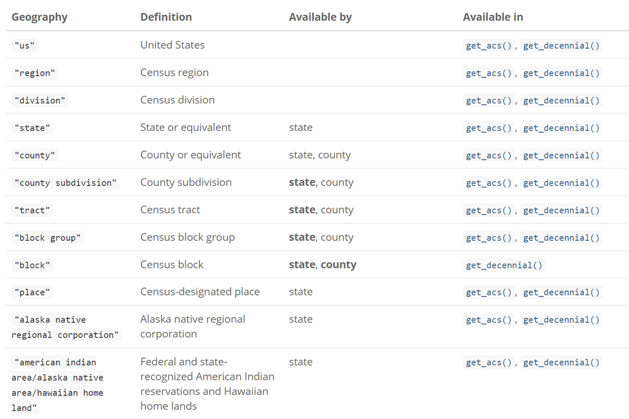

## Searching for Variables

We can search of the potential variables directly in `R`.

```r
variables <- load_variables(2020, "acs5", cache = TRUE)

View(variables)
```

Filtering: Now we can use the filter command to get to our variable(s) of interest quicker.

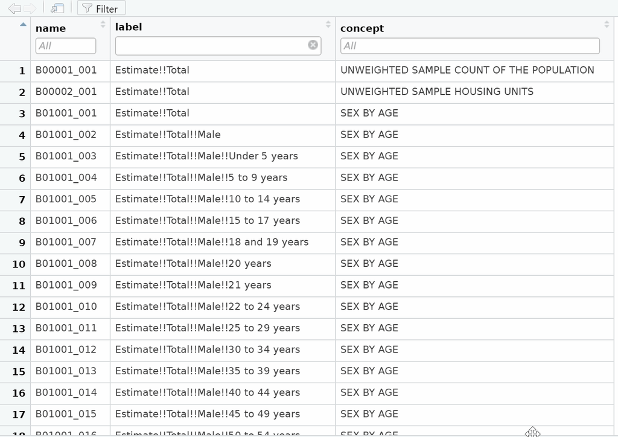

Filtering Variables

## Using `get_acs`

By default, the `get_acs` function pulls the 5-year ACS.

For this example, we will pull the Median income across Virginia Counties

```r
va20 <- get_acs(geography = "county",
              variables = c(medincome = "B19326_001"),
              state = "VA",
              year = 2020)
va20 %>% head()
```

If we would like the 1-year ACS, we would include `survey = "acs1"` explicitly.

```r
va19.acs1 <- get_acs(geography = "county",
              variables = c(medincome = "B19326_001"),
              state = "VA",
              survey = "acs1",
              year = 2019)
va19.acs1 %>% head()
```

### Visualizing the Data

To help our visualization, I will present only the first 30 counties in the plot.

```r
va20[1:30,] %>% ggplot(aes(x = estimate, y = reorder(GEOID,estimate))) +
  labs(title = "Median Income (2016 -- 2020)", y = "County ID") +
  geom_point(color = "hotpink")
```

[output not shown]

### Montgomery county

```r
get_mc <- get_acs(geography = "county", state = 51,
                      county = 121,
                      variables = c(medincome = "B19326_001"),
                      year = 2020)
get_mc %>% head()
```

### Multiple counties

To pull multiple (specific) counties, it would be best to use a loop to achieve this.

```r
#Specify your counties of interest
mycounty <- c(103, 111, 119, 121)

# Before looping start with the first county
get_multi <- get_acs(geography = "county", state = 51,
                      county = mycounty[1],
                      variables = c(medincome = "B19326_001"),
                      year = 2020)

## Pull all other counties of interest in one go
for(i in 2:length(mycounty)){
temp <- get_acs(geography = "county", state = 51,
                      county = mycounty[i],
                      variables = c(medincome = "B19326_001"),
                      year = 2018)

#Combine the counties at each stage of the loop
get_multi <- rbind(get_multi,temp)
}
get_multi %>% head()

ggplot(aes(x = NAME, y = estimate, fill = NAME), data = get_multi) +
  geom_bar(stat = "identity") + theme(legend.position = "none")
```

## Pulling Multiple Variables

Below, we will pull variables across two counties at the tract level. We are most interested in the `Sex by Age` variable.

This time, to filter the variables in the ACS database, we will use the `filter` command from the `tidyverse` package.

Below, we will filter the ACS Data set to get the codes for the `Sex by Age` series. Recall that earlier we used the `load_variable` command to see all the variables in the ACS data base. Also, we stored this in a variable called `variables`. The `Sex by Age` was reported under the `concept` column.

```r
variables %>% filter(concept == "SEX BY AGE")
```

We can quickly see that the code for `Estimate!!Total` is `B01001_001` and `B01001_002` for the `Estimate!!Total!!Male` etc.

Now, we can proceed to pulling data for the 25-39 Age groups for Males. In the later block, we will use the `mutate` function to perform calculations on our variables (and create new variables).

```r
county2 <- c("Montgomery County", "Richmond County")
myvars <- c(
# Sex by AGE

## Total
"B01001_001",

## Male
"B01001_002",

## Males (25-39)
"B01001_011", "B01001_012", "B01001_013")

dat1 <- get_acs(geography = "tract", state = 51,
                county = county2, variables = myvars,
                output = "wide", year = 2020,
                geometry = TRUE,
                keep_geo_vars = TRUE)
dat1 %>% head()
```

Notice the `geometry = TRUE` argument? We will use this to pull the geographical data for the census tracts. In a few, we will produce some basic maps of the data.

### Creating new variables

We need to compute the percentage of Males within 25–39 age group (relative to the total number of males).

For this, we will use the `mutate` argument. The previous variables remain unchanged and the new variable, `age25.39` will be added.

```r
my_acs_tract <- dat1 %>%
  mutate(
  age25.39 = 100*(B01001_011E + B01001_012E + B01001_013E)/B01001_002E
  )

my_acs_tract %>% head()
```

### Plot data

```r
ggplot(aes(x = age25.39, y = TRACTCE, color = TRACTCE), data = my_acs_tract) + geom_point(size = 3) +
  labs(y = NULL, x = "%", title = "Percentage of males in 25 -- 39 Age group") +
  theme(axis.title.y=element_blank(), #Mute the y values
        axis.text.y=element_blank(),
        axis.ticks.y=element_blank())
```

[output not shown]

## Exporting the Data (`.csv`)

We can use the `write.csv` option to export our data to our working directory. This will allow us to manipulate the data further later or use in another program.

For this example, use the `get_multi` data set we created earlier using the loop.

```r
write.csv(get_multi, file = "ACS-county.csv")
```

This is where setting the working directory becomes important. Notice that I did not have to set the adsolute path to my directory. Instead, R will place the data there for me.

**Question:** What about storing the data in a “Data” Folder?

- Within your working directory, create the “Data” folder
- Specify that sub-folder in the `file` argument when writing the `.csv` file.

```r
write.csv(get_multi, file = "Data/ACS-county.csv")
```

## Importing the Data (`.csv`)

Now let us re-import the data (saved in the Data folder) into our R session. We will call it `import.mult` so that we can distinguish it from the original dataset above.

We will use the `read.csv` function here.

```r
import.mult <- read.csv("Data/ACS-county.csv")
```

## Plot Data

As promised, here is a flavor of how to produce quick maps using the `tidycensus` package.

For this exercise, we will plot the percentages of males computed and stored in the `my_acs_tract` dataset.

**Method 1: Using the `plot` function**

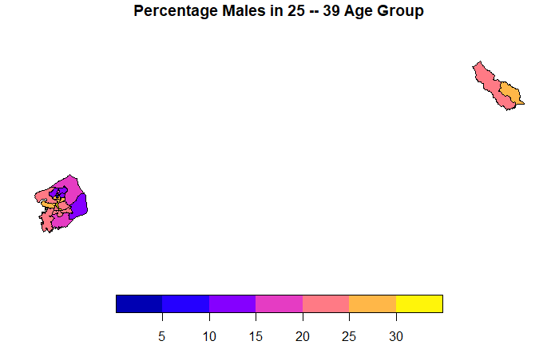

```r
plot(my_acs_tract["age25.39"],
     main = "Percentage Males in 25 -- 39 Age Group",
     caption = "Tested")
```

**Method 2: Using the `ggplot` function**

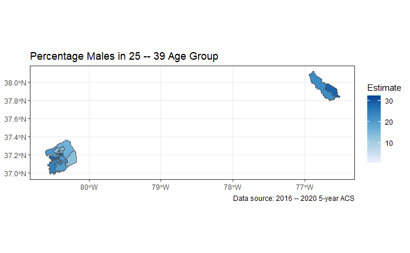

```r
ggplot(data = my_acs_tract, aes(fill = age25.39)) +
  geom_sf() +
  scale_fill_distiller(palette = "Blues",
                       direction = 1) +
  labs(title = "Percentage Males in 25 -- 39 Age Group",
       caption = "Data source: 2016 -- 2020 5-year ACS",
       fill = "Estimate") +
  theme_bw()
```

## Your Turn

For this exercise, your task is to pull the median household income across all states in the U.S. in 2020.

- Pull the data and store it into a variable called `med.income`. Be sure to add the `geometry = TRUE` argument to store the mapping data.
  - You might need to do a filter of the variables to find the code.
- Use the `head()` command to get a feel for your data.

```r
##Start here
```

```r
#start here
```

## Need More R Help?

Chapter 13 of this Data Wrangling website might prove useful: https://dcl-wrangle.stanford.edu/census.html